# Introduction to pliable

Rob Tibshirani

2020-02-06

## Introduction

`pliable` is a package that fits the pliable lasso, a new method for obtaining sparse models for supervised learning problems. The pliable lasso takes as input the usual feature matrix X and response y , but also a matrix of modifying variables Z. These variables may be continuous or categorical. The pliable lasso model is a generalization of the lasso in which the coefficients multiplying the features X are allowed to vary as a function of the modifying variables Z.

We introduce some notation that we will use throughout this vignette. Let there be $n$ observations, each with feature vector $x_i \in \mathbb{R}^p$ and response $y_i$. Let $X \in \mathbb{R}^{n \times p}$ denote the overall feature matrix, and let $y \in \mathbb{R}^n$ denote the vector of responses. Finally, let $Z \in \mathbb{R}^{n \times nz}$ denote the matrix of modifying variables.

`pliable` fits the model

$$\hat y = \beta_0+ Z\theta_0+ \sum_j X_j(\beta_j + Z\theta_j)$$

where $X_j$ is the $j$th column of $X$. Here each $\beta_j$ is a scalar and each $\theta_j$ is a vector of length $nz$. The model is fit with penalties that encourage both $\beta=(\beta_1, \ldots \beta_p)$ and each $\theta_j$ to be sparse, and also a hierarchy constraint that allows $\theta_j$ to be non-zero only if $\beta_j$ is non zero. Note that each $\theta_j$ represents an interaction between $X_j$ and all of $Z$. Details of the optimization may be found in the paper by Tibshirani and Friedman [arXiv](https://arxiv.org/abs/1712.00484).

`pliable` uses cyclical coordinate descent, which successively optimizes the objective function over each parameter with all other parameters fixed, cycling repeatedly until convergence. The interaction terms $\theta_j$ are estimated by proximal gradient descent.

The package also includes methods for prediction and plotting, and a function which performs $k$-fold cross-validation.

## Installation

We begin by installing `pliable` from CRAN. Type the following command in R console:

```r
install.packages("pliable")
```

This command downloads the R package and installs it to the default directories. Users may change add a `repos` option to the function call to specify which repository to download from, depending on their locations and preferences.

Alternatively, users can download the package source at CRAN and type Unix commands to install it to the desired location.

## Quick Start

The purpose of this section is to give users a general sense of the package. We will briefly go over the main functions of the package, as well as some key options. More details are given in later sections.

First, we load the `pliable` package:

```r
library(pliable)
```

Let’s generate some data:

```r
set.seed(944)
n = 50; p = 10 ;nz=5
x = matrix(rnorm(n*p), n, p)
mx=colMeans(x)
sx=sqrt(apply(x,2,var))
x=scale(x,mx,sx)
z =matrix(rnorm(n*nz),n,nz)
mz=colMeans(z)
sz=sqrt(apply(z,2,var))
z=scale(z,mz,sz)
y =4*x[,1] +5*x[,1]*z[,3]+ 3*rnorm(n)
```

We recommend that the columns of both $X$ and $Z$ be standardized, before running `pliable`, as we have done above.

We fit the model using the most basic call to `pliable`:

```r
fit <- pliable(x,z,y)
```

The function `pliable` returns a `pliable` object. We can examine the results

```r
fit
```

[output not shown]

[output cut: 39 more lines]

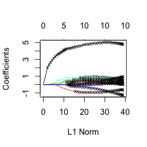

```r
plot(fit)
```

And we can make predictions using a `pliable` object by calling the `predict` method. Each column gives the predictions for one value of `lambda`. Here we choose the 20th value:

```r
# get predictions for 20th model
predict(fit, x[1:5, ],z[1:5,])[,20]
```

```
#> [1]   3.903689 -14.024664  15.182350   2.066809  -2.925222
```

### Cross-validation (CV)

We can perform $k$-fold cross-validation (CV) with `cv.pliable`. It does 10-fold cross-validation by default:

```r
cvfit <- cv.pliable(fit,x, z, y)
```

We can change the number of folds using the `nfolds` option:

```r
cvfit <- cv.pliable(fit, x, z,y , nfolds = 5)
```

If we want to specify which observation belongs to which fold, we can do that by specifying the `foldid` option, which is a vector of length $n$, with the $i$th element being the fold number for observation $i$.

```r
foldid <- sample(rep(seq(5), length = n))
cvfit <- cv.pliable(fit, x,z,y, foldid = foldid)
```

A `cv.pliable` call returns a `cv.pliable` object. We can plot this object to get the CV curve with error bars (one standard error in each direction). The left vertical dotted line represents `lambda.min`, the `lambda` value which attains minimum CV error, while the right vertical dotted line represents `lambda.1se`, the largest `lambda` value with CV error within one standard error of the minimum CV error.

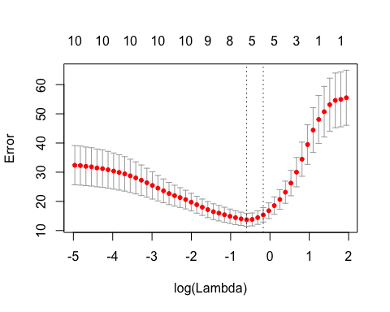

```r
plot(cvfit)
```

The two special `lambda` values can be extracted directly from the `cv.pliable` object as well:

```r
cvfit$lambda.min
```

```
#> [1] 0.5522866
```

```r
cvfit$lambda.1se
```

```
#> [1] 0.8430201
```

Predictions can be made from the fitted `cv.pliable` object. By default, predictions are given for `lambda` being equal to `lambda.1se`. To get predictions are `lambda.min`, set `s = "lambda.min"`.

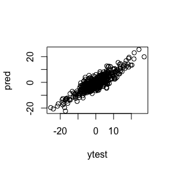

```r
set.seed(44)
ntest=500
xtest = matrix(rnorm(ntest*p),ntest,p)
xtest=scale(xtest,mx,sx)
ztest =matrix(rnorm(ntest*nz),ntest,nz)
ztest=scale(ztest,mz,sz)
ytest = 4*xtest[,1] +5*xtest[,1]*ztest[,3]+ 3*rnorm(ntest)
pred= predict(fit,xtest,ztest,lambda=cvfit$lambda.min)
plot(ytest,pred)
```

### Categorical Z

If $Z$ is categorical, you much first convert it to set of dummy variables (``one-hot encoding’’). Suppose that that you have two $Z$ variables, a categorical one $Z1= (3,1,4,2,2,1,3)$ and a quantitative variable $Z2$. Then you would convert $Z1$ to dummy variables, using say $D=model.matrix(~Z)$ and then define $Z$ as $Z <- cbind(D,Z2)$

### Z not observed in test set

Here is an example where Z is not observed in the test set, but predicted from a supervised learning algorithm

```r
 n = 50; p = 10 ;nz=5
 x = matrix(rnorm(n*p), n, p)
 mx=colMeans(x)

 sx=sqrt(apply(x,2,var))
 x=scale(x,mx,sx)
 z =matrix(rnorm(n*nz),n,nz)
 mz=colMeans(z)
 sz=sqrt(apply(z,2,var))
 z=scale(z,mz,sz)
 y =4*x[,1] +5*x[,1]*z[,3]+ 3*rnorm(n)

 fit = pliable(x,z,y)
 # predict z  from x; here we use glmnet, but any other supervised method can be used

 zfit=cv.glmnet(x,z,family="mgaussian")

 # Predict using the fitted model
 ntest=500
 xtest =matrix(rnorm(ntest*nz),ntest,p)
 xtest=scale(xtest,mx,sx)
 ztest =predict(zfit,xtest,s=cvfit$lambda.min)[,,1]
 ytest = 4*xtest[,1] +5*xtest[,1]*ztest[,3]+ 3*rnorm(ntest)

 pred= predict(fit,xtest,ztest)
```

## Other options

Here are some other options that one may specify for the `pliable` and `cv.pliable` functions:

- `w`: The user can pass a vector of length $n$ representing observation weights. The squared residual of the observations are weighted according to this vector. By default, this is set to 1 for all observations.
- `family`: The default value for the `family` option of the `pliable` and `cv.pliable` functions is `gaussian`. Use this default when `y` is a quantitative variable (i.e. takes values along the real number line). For binary prediction, use `family = binomial`. In this setting, the response `y` should be a numeric vector containing just 0s and 1s.
- `lambda`: The `lambda` sequence at which the model fit will be computed. This is typically not provided by the user: the program can construct the sequence on its own. When automatically generated, the `lambda` sequence is determined by `lambda.max` (internally computed) and `lambda.min.ratio`. (`lambda.min.ratio` is the ratio of smallest value of the generated `lambda` sequence, say `lambda.min`, to `lambda.max`.) The program generates `nlam` values (default is 50) linear on the log scale from `lambda.max` down to `lambda.min`.
- `standardize`: If set to `TRUE`, the columns of the feature matrix `x` are scaled to have unit variance before the algorithm is run.

For more information, type `?pliable` or `?cv.pliable`.